# Carter Athens

Carter Athens

April 16, 2019

```r
library(dplyr)
```

```r
library(ggplot2)
library(lubridate)
library(tidyverse)
library(readxl)
acc <- read.csv("https://raw.githubusercontent.com/xdaiISU/ds202materials/master/hwlabs/fars2017/accident.csv", stringsAsFactors = FALSE)
per <- read.csv("https://raw.githubusercontent.com/xdaiISU/ds202materials/master/hwlabs/fars2017/person.csv", stringsAsFactors = FALSE)
names(acc)
```

```
##  [1] "STATE"      "ST_CASE"    "VE_TOTAL"   "VE_FORMS"   "PVH_INVL"
##  [6] "PEDS"       "PERNOTMVIT" "PERMVIT"    "PERSONS"    "COUNTY"
## [11] "CITY"       "DAY"        "MONTH"      "YEAR"       "DAY_WEEK"
## [16] "HOUR"       "MINUTE"     "NHS"        "RUR_URB"    "FUNC_SYS"
## [21] "RD_OWNER"   "ROUTE"      "TWAY_ID"    "TWAY_ID2"   "MILEPT"
## [26] "LATITUDE"   "LONGITUD"   "SP_JUR"     "HARM_EV"    "MAN_COLL"
## [31] "RELJCT1"    "RELJCT2"    "TYP_INT"    "WRK_ZONE"   "REL_ROAD"
## [36] "LGT_COND"   "WEATHER1"   "WEATHER2"   "WEATHER"    "SCH_BUS"
## [41] "RAIL"       "NOT_HOUR"   "NOT_MIN"    "ARR_HOUR"   "ARR_MIN"
## [46] "HOSP_HR"    "HOSP_MN"    "CF1"        "CF2"        "CF3"
## [51] "FATALS"     "DRUNK_DR"
```

```r
names(per)
```

```
##  [1] "STATE"      "ST_CASE"    "VE_FORMS"   "VEH_NO"     "PER_NO"
##  [6] "STR_VEH"    "COUNTY"     "DAY"        "MONTH"      "HOUR"
## [11] "MINUTE"     "RUR_URB"    "FUNC_SYS"   "HARM_EV"    "MAN_COLL"
## [16] "SCH_BUS"    "MAKE"       "MAK_MOD"    "BODY_TYP"   "MOD_YEAR"
## [21] "TOW_VEH"    "SPEC_USE"   "EMER_USE"   "ROLLOVER"   "IMPACT1"
## [26] "FIRE_EXP"   "AGE"        "SEX"        "PER_TYP"    "INJ_SEV"
## [31] "SEAT_POS"   "REST_USE"   "REST_MIS"   "AIR_BAG"    "EJECTION"
## [36] "EJ_PATH"    "EXTRICAT"   "DRINKING"   "ALC_DET"    "ALC_STATUS"
## [41] "ATST_TYP"   "ALC_RES"    "DRUGS"      "DRUG_DET"   "DSTATUS"
## [46] "DRUGTST1"   "DRUGTST2"   "DRUGTST3"   "DRUGRES1"   "DRUGRES2"
## [51] "DRUGRES3"   "HOSPITAL"   "DOA"        "DEATH_DA"   "DEATH_MO"
## [56] "DEATH_YR"   "DEATH_HR"   "DEATH_MN"   "DEATH_TM"   "LAG_HRS"
## [61] "LAG_MINS"   "P_SF1"      "P_SF2"      "P_SF3"      "WORK_INJ"
## [66] "HISPANIC"   "RACE"       "LOCATION"
```

Part one: Accident data

Are there some days of the week where more accidents happen than on others (use variable DAY_WEEK)? The most accidents happen on Saturday. Sunday and Friday also have a lot more accidents than the rest of the week.

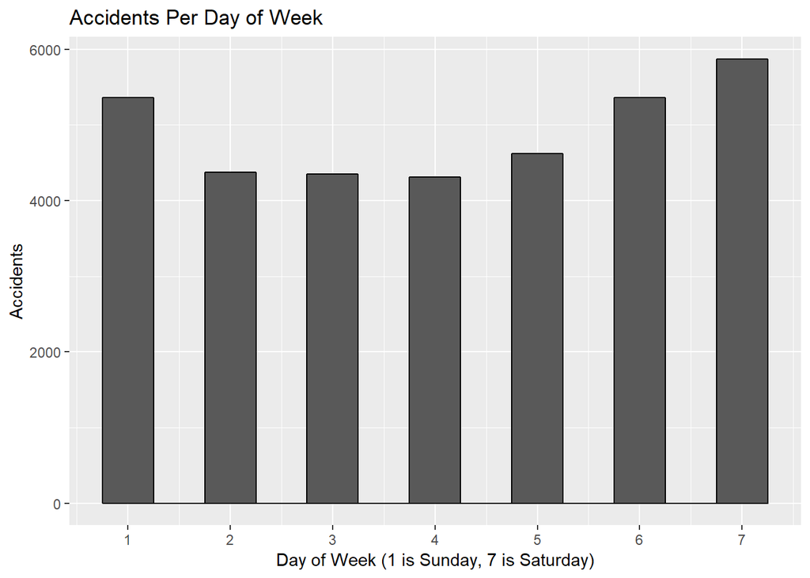

```r
ggplot(acc, aes(x=DAY_WEEK)) + geom_histogram(color="black", binwidth = .5) + scale_x_continuous(breaks=seq(1,7,1)) + xlab("Day of Week (1 is Sunday, 7 is Saturday)") + ylab("Accidents") + ggtitle("Accidents Per Day of Week")
```

What time of the day do accidents happen (use variable HOUR)? Most accidents happen around hour 18. This is because most people are getting off work.

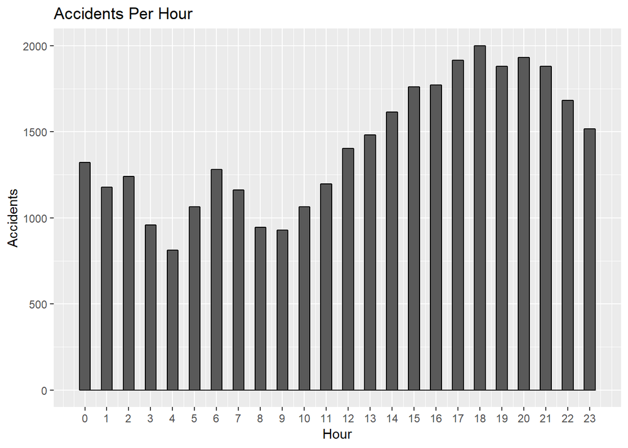

```r
acc <- acc[!(acc$HOUR == "99"),] # The HOUR column has some wrong values so I removed them
ggplot(acc, aes(x=HOUR)) + geom_histogram(color="black", binwidth = .5) + scale_x_continuous(breaks=seq(0,23,1)) + xlab("Hour") + ylab("Accidents") + ggtitle("Accidents Per Hour")
```

```r
numAccWithDrunkDriver <- filter(acc, DRUNK_DR > 0)
dim(numAccWithDrunkDriver)
```

```
## [1] 8667   52
```

```r
print(dim(numAccWithDrunkDriver))
```

```
## [1] 8667   52
```

Part two: Connecting data

Load the person table. Identify drivers (PER_TYP == 1, see fars manual) and subset on them. Join accident and driver table (work out which variable(s) to use). Tally the number of accidents by day of the week (DAY_WEEK), hour of the day (HOUR) and gender (SEX). Visualize the results!

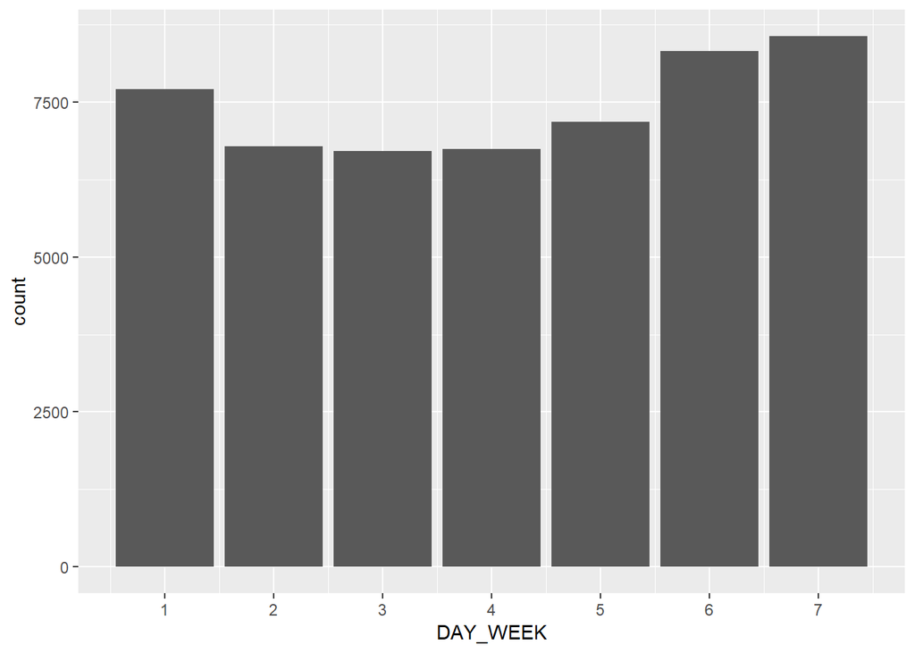

```r
drivers <- per %>% filter(PER_TYP == 1)

drivers %>% select(-c(HOUR)) %>% left_join(acc, by="ST_CASE") %>% group_by(DAY_WEEK) %>% summarise(count = n()) %>% ggplot(aes(x=DAY_WEEK)) + scale_x_continuous(breaks=seq(1,7,1)) + geom_bar(aes(weight=count))
```

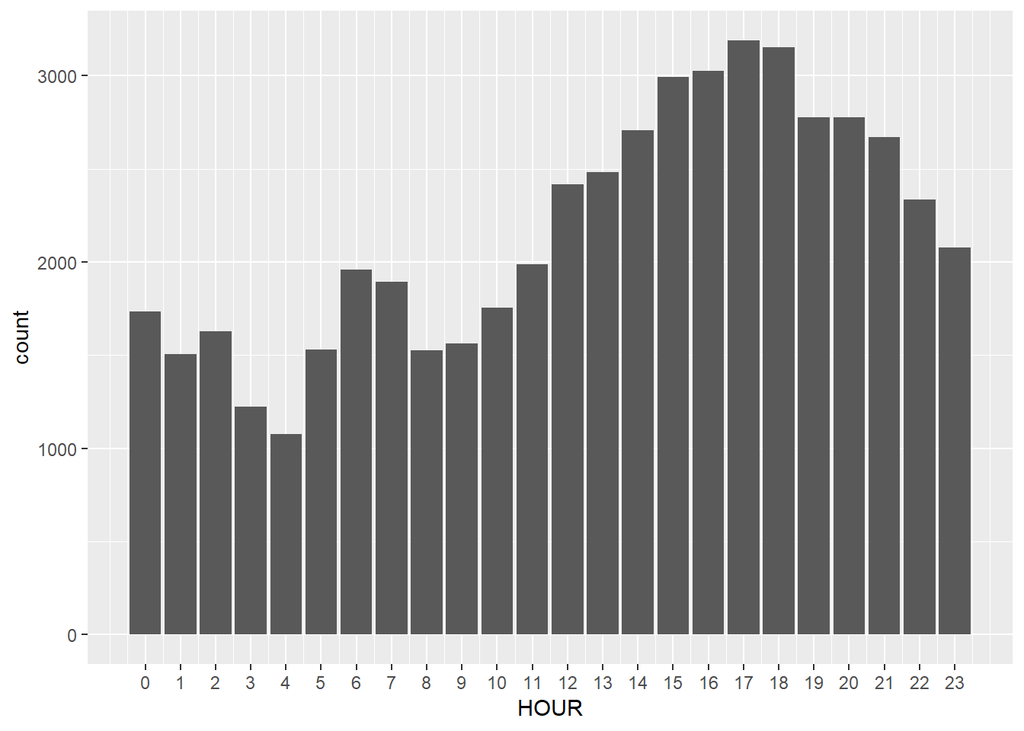

```r
# There are more accidents on Sunday, Friday, and Saturday.

drivers %>% select(-c(HOUR)) %>% left_join(acc, by="ST_CASE") %>% group_by(HOUR) %>% summarise(count = n()) %>% ggplot(aes(x=HOUR)) + scale_x_continuous(breaks=seq(0,23,1)) + geom_bar(aes(weight=count))
```

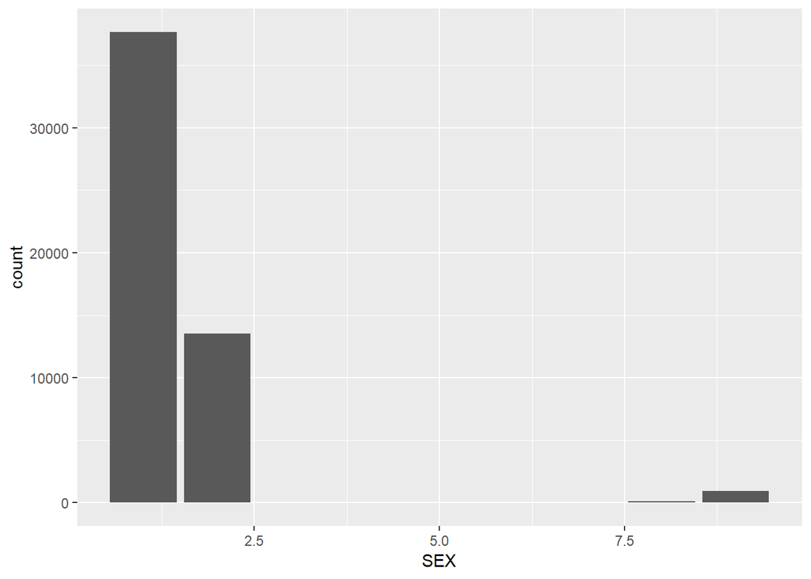

```r
# Most accidents happen during rush hour when people are getting off work.

drivers %>% select(-c(HOUR)) %>% left_join(acc, by="ST_CASE") %>% group_by(SEX) %>% summarise(count = n()) %>% ggplot(aes(x=SEX)) + geom_bar(aes(weight=count))
```

```r
# Men are involved in accidents significantly more often than women.
```

Part three: Connecting data and make maps

Now plot a choropleth map of accidents on a county level. Read the description for the STATE and COUNTY columns in the FARS manual. Visualize the number of accidents in each county using a choropleth map. To do this, you need to join the accident data, GLCs, and appropriate map data. Can you find seasonal trends in accident occurrences in different states? Is summer or winter more dangerous? Why?

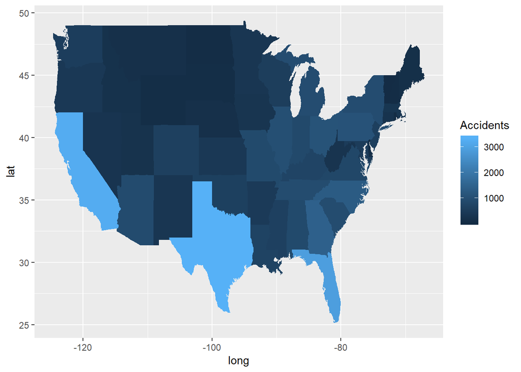

```r
states <- map_data('state')
glc <- read_excel("FRPP GLC United States.xlsx", skip = 1)
acc1 <- acc %>% group_by(STATE) %>% summarize(Accidents = n())
colnames(glc)[colnames(glc) == 'State Code'] <- 'STATE'
glc$STATE <- as.numeric(glc$STATE)
states$region <- toupper(states$region)
colnames(states)[colnames(states) == 'region'] <- 'State Name'
glc1 <- glc %>% select(`State Name`, STATE)
glc2 <- distinct(glc1)
dat1 <- inner_join(acc1, glc2, by = 'STATE')
states1 <- inner_join(dat1, states, by = 'State Name')

ggplot(states1, aes(x = long, y = lat, fill = Accidents)) + geom_polygon(aes(group = group))
```

I dont know how to do the counties because there were multiple counties with a duplicate code, so I used the state data instead.

California, Texas, and Florida have the most amount of accidents but this probably doesn’t mean much because their populations are much higher than the rest of the other states.

The winter months in more northern states would have more accidents because of the poor road conditions. The more southern states wouldn’t see this trend as they don’t have the same weather.